# Inequality in Agency Rulemaking

Daniel P. Carpenter, Angelo Dagonel, Devin Judge-Lord, Christopher T. Kenny, Brian Libgober, Steven Rashin, Jacob Waggoner, Susan Webb Yackee

[figure not shown]

[figure not shown]

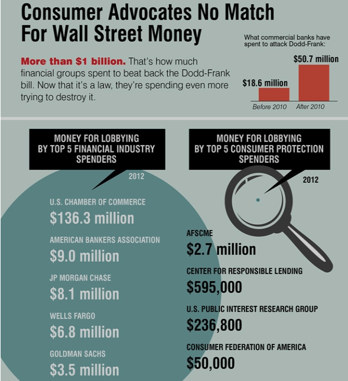

## Does wealth mean power in agency rulemaking?

### If so, why?

- Are wealthy organizations structurally advantaged (i.e., do they always win)?
- Or do they win *because* of their lobbying (i.e., because it is more sophisticated)?
  - not mutually exclusive. But *how much* influence is due to lobbying?

## The Headlines

💰 $\rightsquigarrow$ seat at the table

- Wealthier organizations are more likely to comment
- Among commenters, frequent commenters are wealthier

💰 $\rightsquigarrow$ sophistication (e.g., lawyers) $\rightsquigarrow$ lobbying success

- Wealthy organizations submit more sophisticated comments
- Agencies adopt more language from sophisticated comments
- Much of the relationship between wealth and lobbying success can be attributed to lobbying sophistication<sup>1</sup>
[^1]: We observe only a type of influence that is most likely to be the result of specific sophisticated lobbying.

## 📊 DATA

- All Dodd-Frank Rules (800+ policy documents) 2010-2018
- All ~300k comments on these rules
- Linked to 6k+ organizations (+ all ~500k similar orgs. that did not comment)

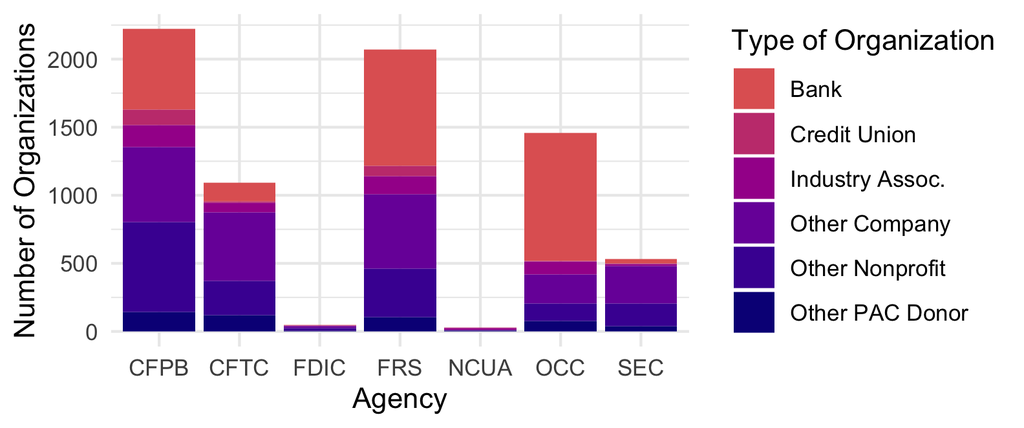

Figure 1: Number of Organizations by Type and Agency to which they Commented

## 💰 $\rightsquigarrow$ seat at the table

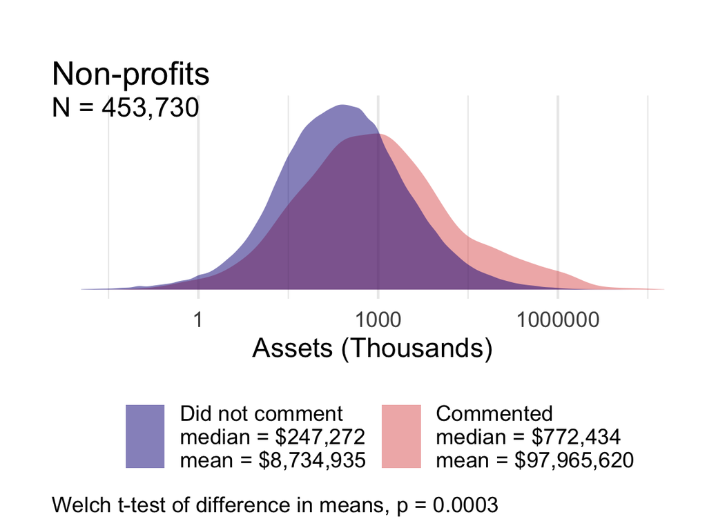

Financial Resources of Organizations that Did and Did Not Comment

## 💰 $\rightsquigarrow$ seat at the table

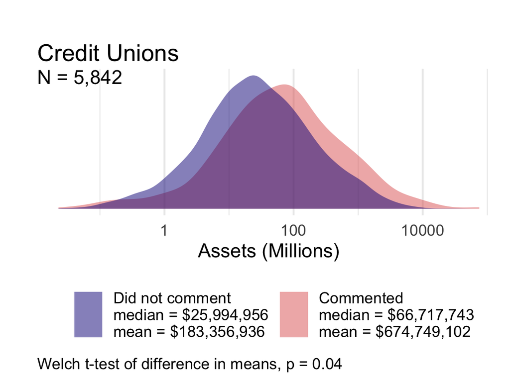

Financial Resources of Organizations that Did and Did Not Comment

## 💰 $\rightsquigarrow$ seat at the table

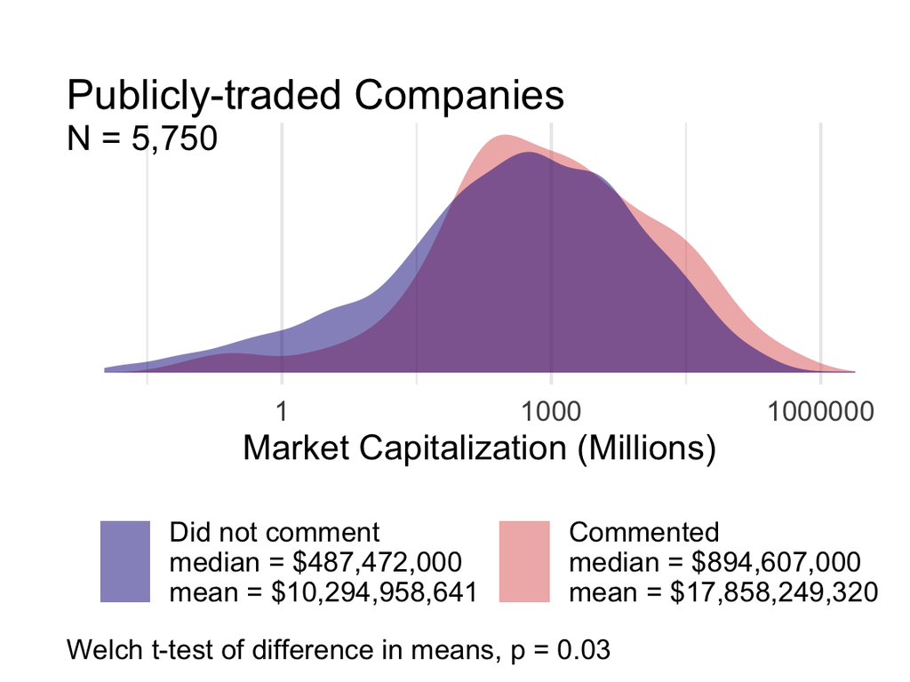

Financial Resources of Organizations that Did and Did Not Comment

## 💰 $\rightsquigarrow$ seat at the table

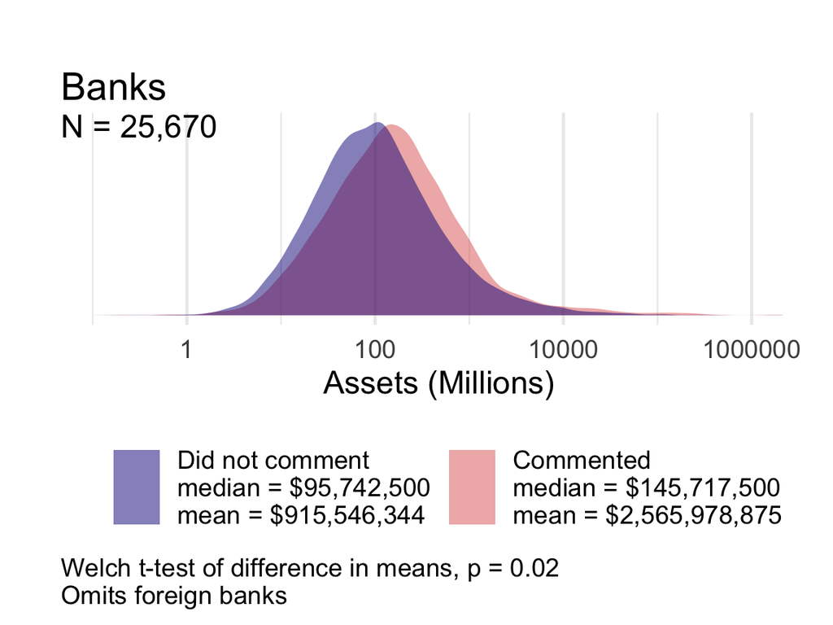

Financial Resources of Organizations that Did and Did Not Comment

## 💰 $\rightsquigarrow$ seat at the table, especially if profit-motivated

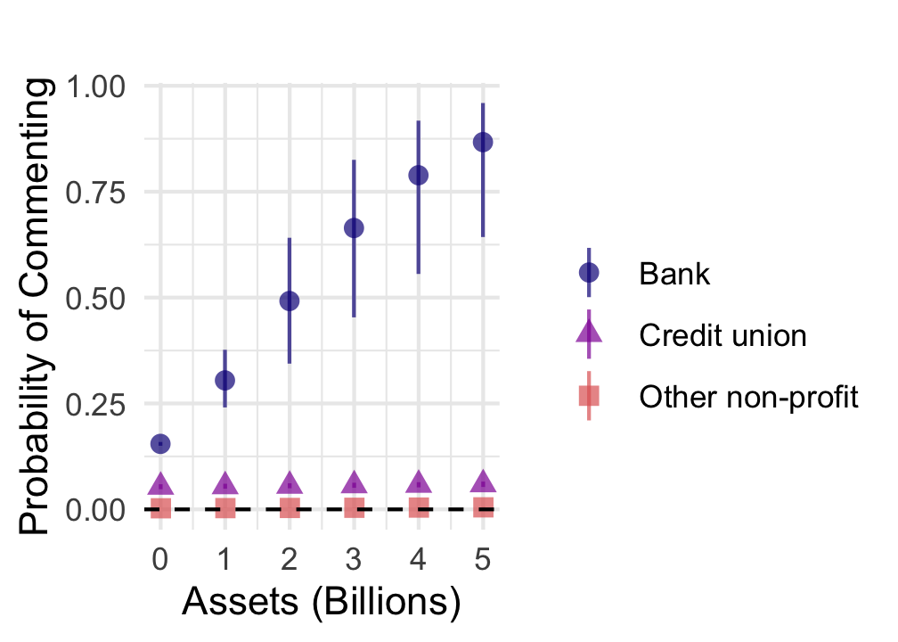

Predicted Probability of Participating in Dodd-Frank Rulemaking by Assets

## 💰 $\rightsquigarrow$ seat at the table, especially if profit-motivated

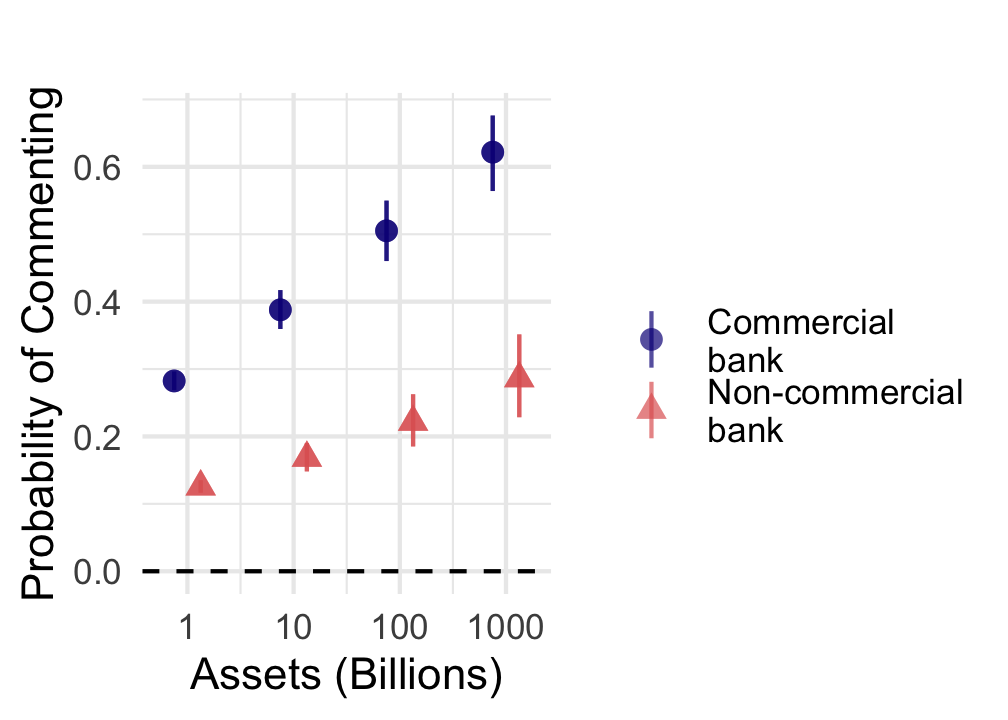

Predicted Probability of Participating by Type of Bank

## Lobbying Success

[figure not shown]

## 💰 $\rightsquigarrow$ lobbying success (banks)

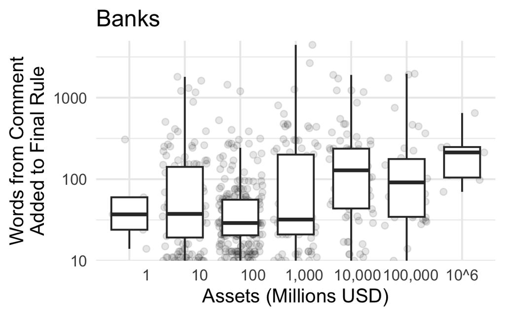

Amount of Text Repeated in Final Rules by Commenter Resources.

## 💰 $\rightsquigarrow$ lobbying success (companies)

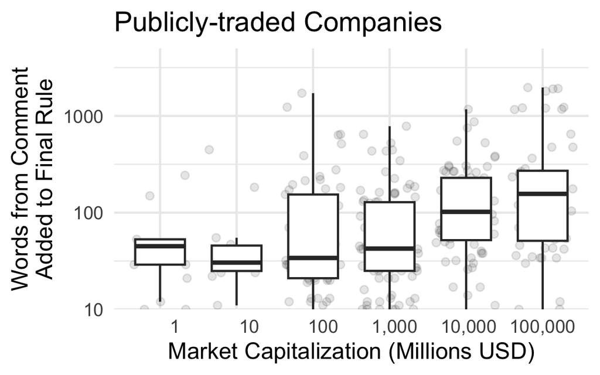

Amount of Text Repeated in Final Rules by Commenter Resources.

## 💰 $\rightsquigarrow$ sophistication (e.g., lawyers) $\rightsquigarrow$ lobbying success

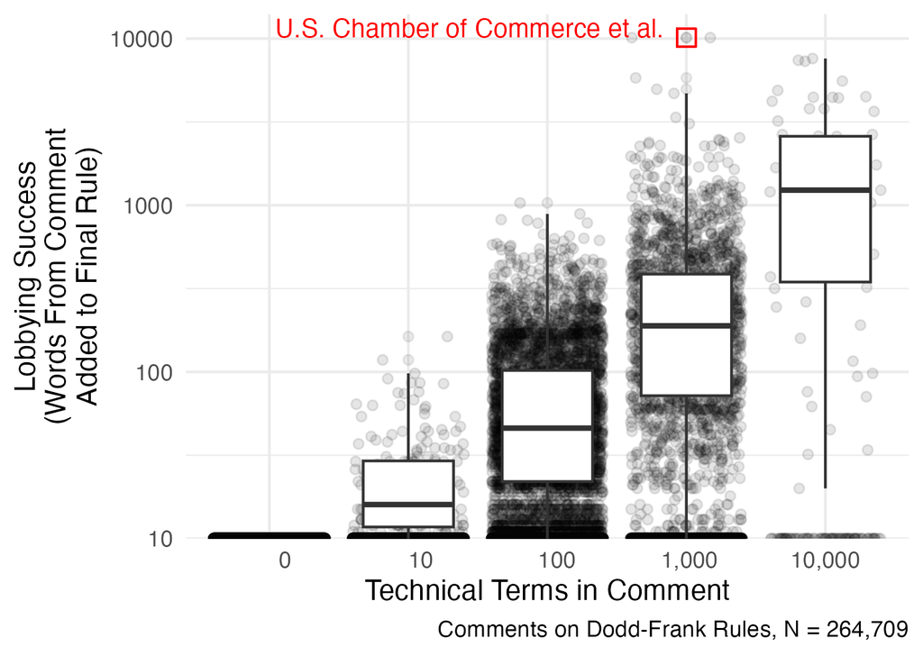

Figure 2: Lobbying Success by Comment Sophistication.

## 💰 $\rightsquigarrow$ sophistication (e.g., lawyers) $\rightsquigarrow$ lobbying success

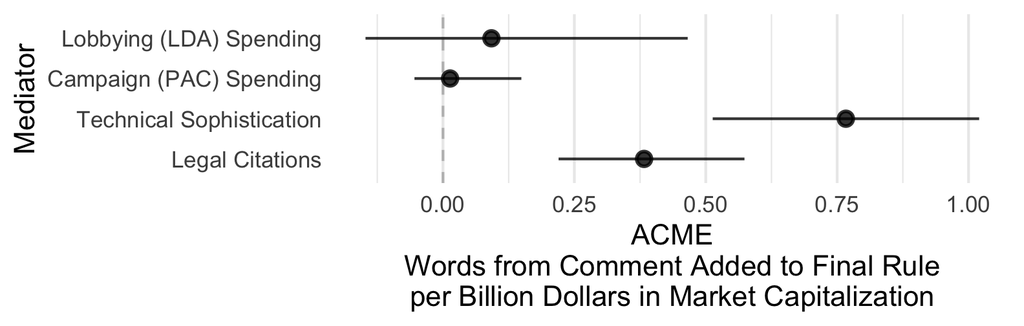

Lobbying Success by Comment Sophistication

## RECAP

💰 $\rightsquigarrow$ seat at the table

- Wealthier organizations are more likely to comment
- Among commenters, frequent commenters are wealthier

💰 $\rightsquigarrow$ sophistication (e.g., lawyers) $\rightsquigarrow$ lobbying success

- Wealthy organizations submit more sophisticated comments
- Agencies adopt more text from sophisticated comments
- Much of the relationship between wealth and lobbying success can be attributed to lobbying sophistication

## Alternative (?) explanations

- Sophistication is just stylistic emulation
- Comments from wealthy organizations are easier to accommodate

(but sophisticated comments get cites)

## Alternative interpretations

- sophisticated comments are just more “correct” (?)
- the wealthy have greater stakes (?)
- This is good, actually. Wealthier organizations “represent” more people (?)
  - Nonprofit volunteers? members vs. memberless? (❌)
  - employees? customers? shareholders?
  - regulated industry vs. consumers?
  - narrow private aims (US Chambers) vs. broad public aims (US PIRG)?
  - 501(c) 3 vs 4 vs 5 vs 6 (🔜)

# 🙏 Feedback

- Setup & theoretical contribution
- Thoughts on matching
- Dealing with relevance/stakes conceptually
- Omitted variables
- [Validation](https://judgelord.github.io/finreg/validation)
- Do we need to model a selection process?

## Next:

- Compare lobbying on rules that regulate big banks vs. other rules
- **Benchmarks** to compare lobbying inequality across Congress and the bureaucracy?
- Assess other **mechanisms**?
  - legislator comments
- Dimensions of variation across **venues** or policy **domains**?

# Extra

## Participation by Market Capitalization

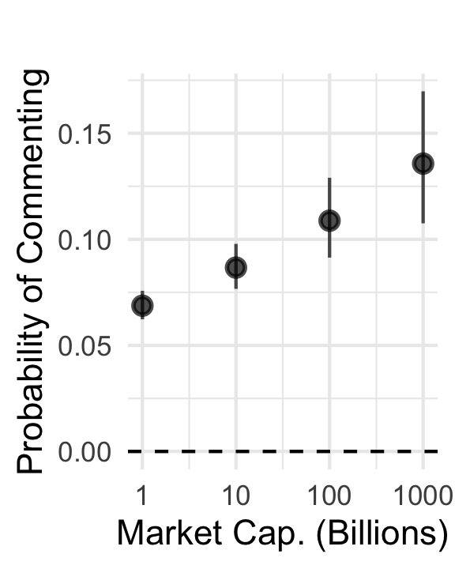

Figure 3: Predicted Probability of Participating in Dodd-Frank Rulemaking by Market Capitalization

## Participation Table

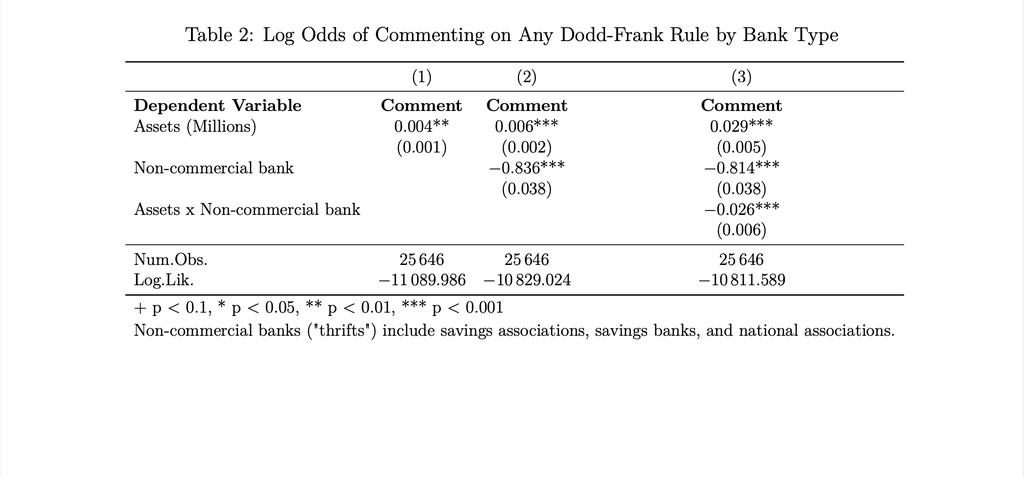

## 💰 $\rightsquigarrow$ lobbying success (nonprofits)

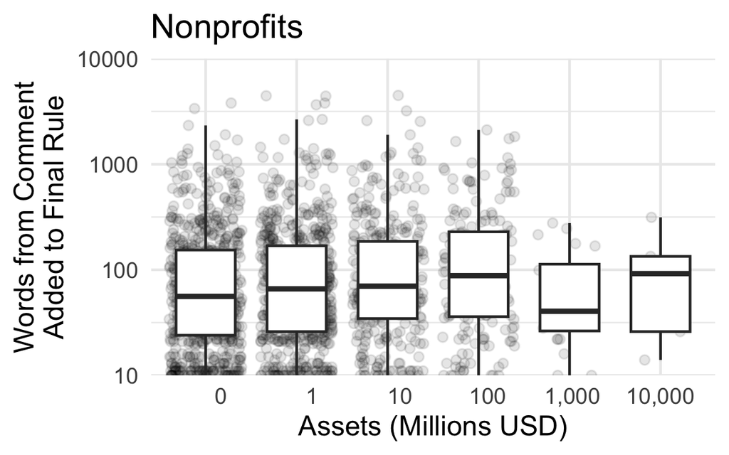

Amount of Text Repeated in Final Rules by Commenter Resources.

## 💰 $\rightsquigarrow$ lobbying success (credit unions)

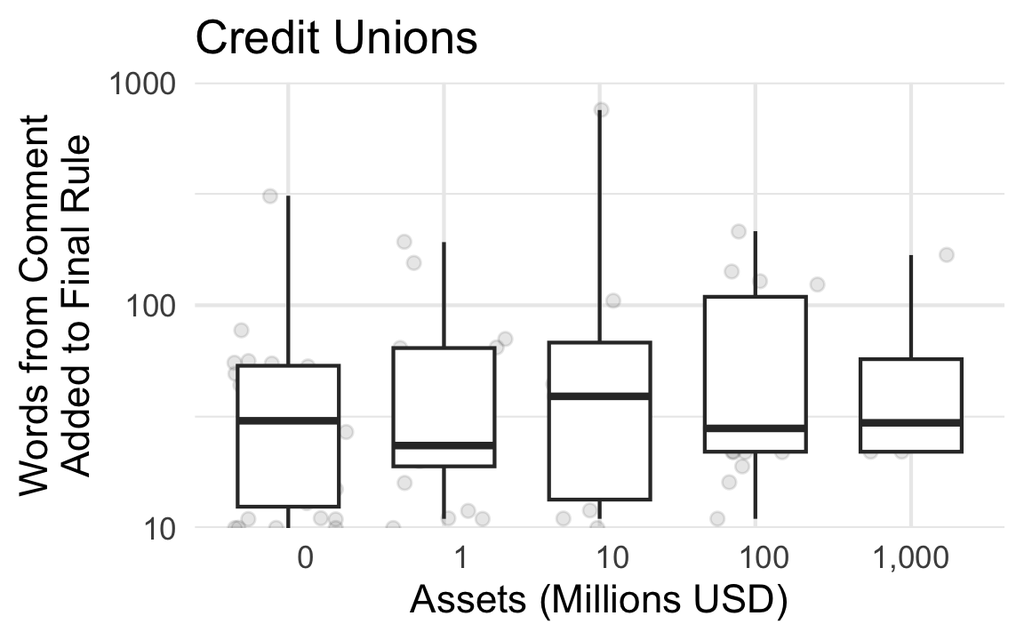

Amount of Text Repeated in Final Rules by Commenter Resources.

## 💰 $\rightsquigarrow$ lobbying success (industry assn.)

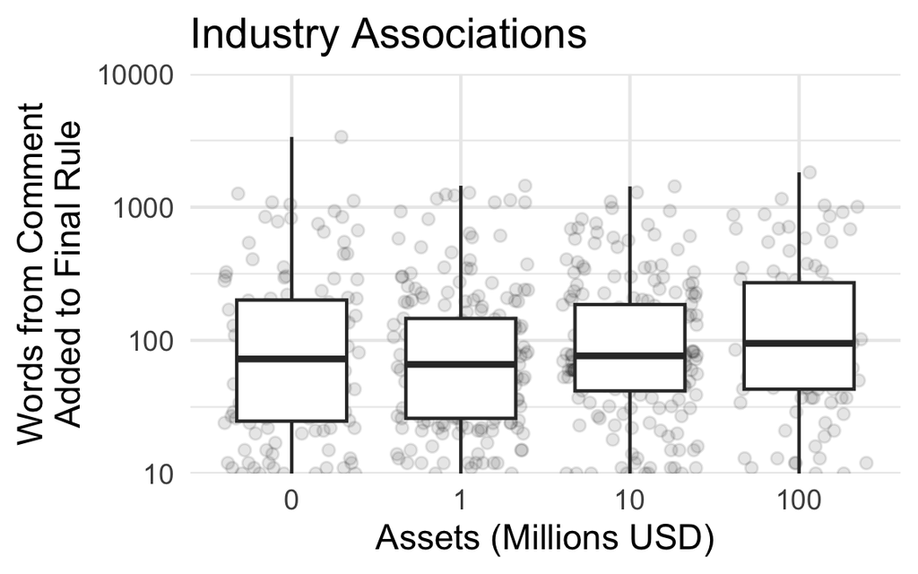

Amount of Text Repeated in Final Rules by Commenter Resources.

## 💰 $\rightsquigarrow$ lobbying success

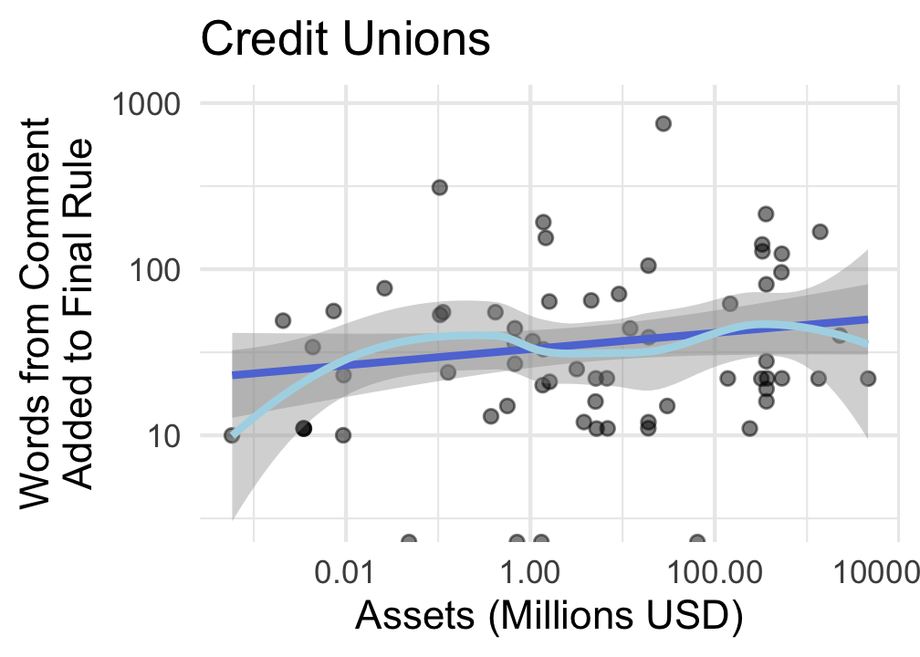

Amount of Text Repeated in Final Rules by Commenter Resources

## 💰 $\rightsquigarrow$ lobbying success

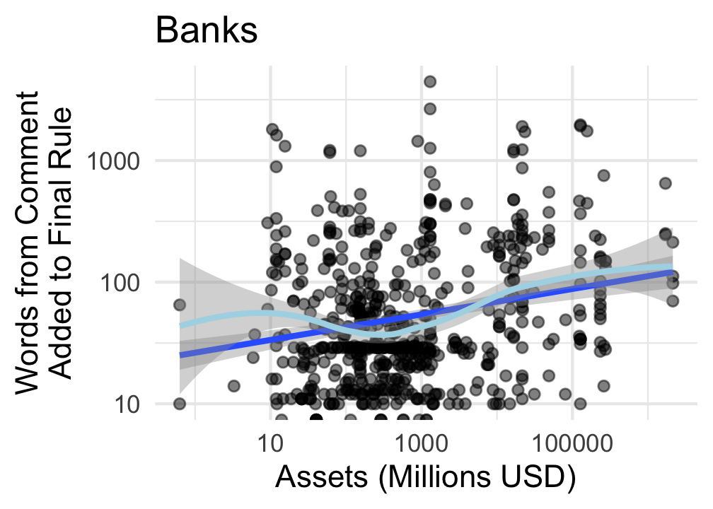

Amount of Text Repeated in Final Rules by Commenter Resources

## 💰 $\rightsquigarrow$ lobbying success

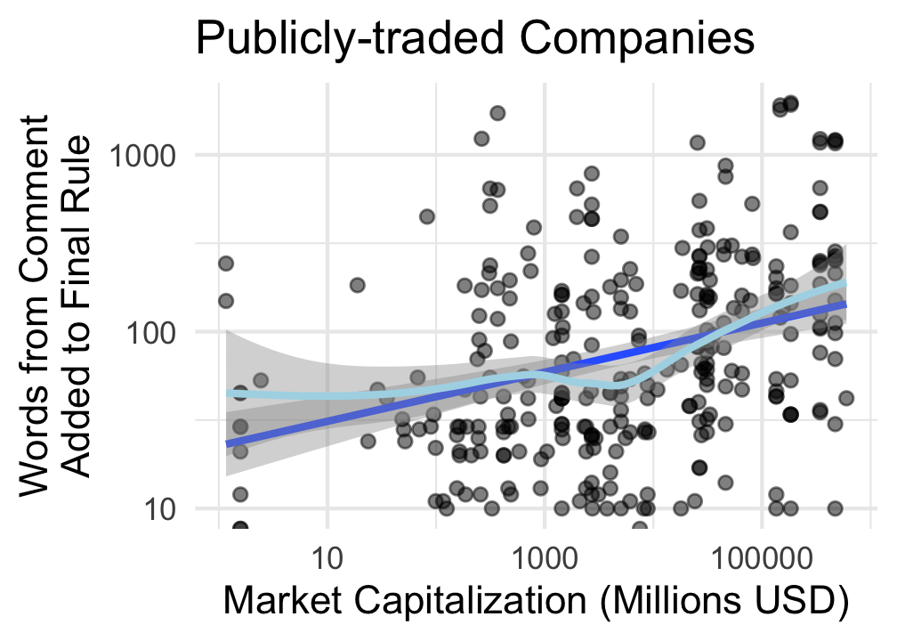

Amount of Text Repeated in Final Rules by Commenter Resources

## ACME 💰 $\rightsquigarrow$ PAC Donations $\nrightarrow$ lobbying success

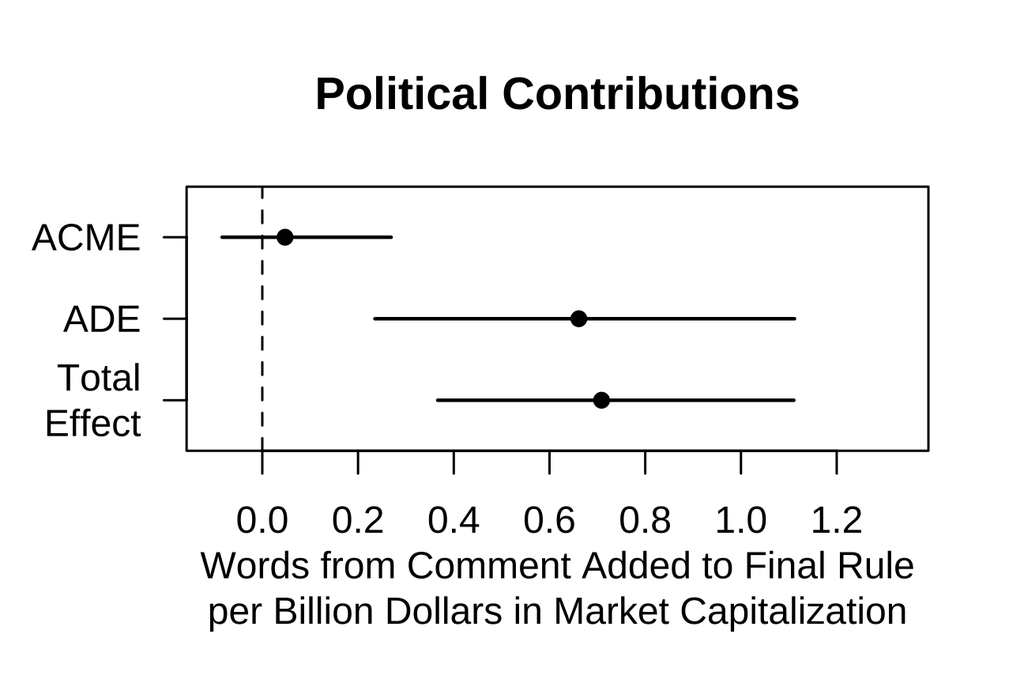

PAC Donations as a Mediator Between Wealth and Lobbying Success

## Technical Terms by Assets

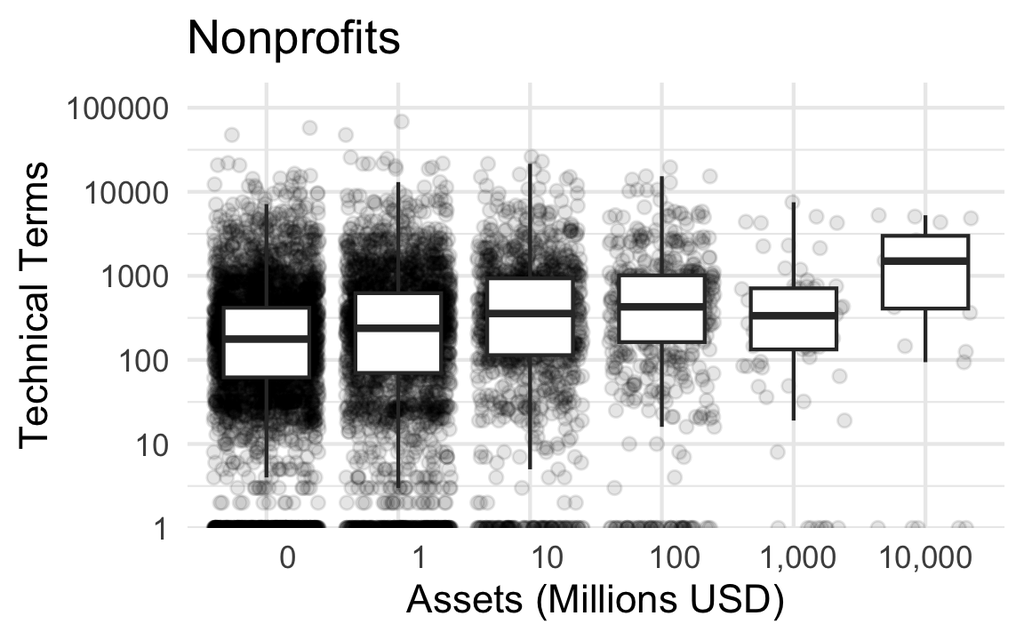

(a) Nonprofits

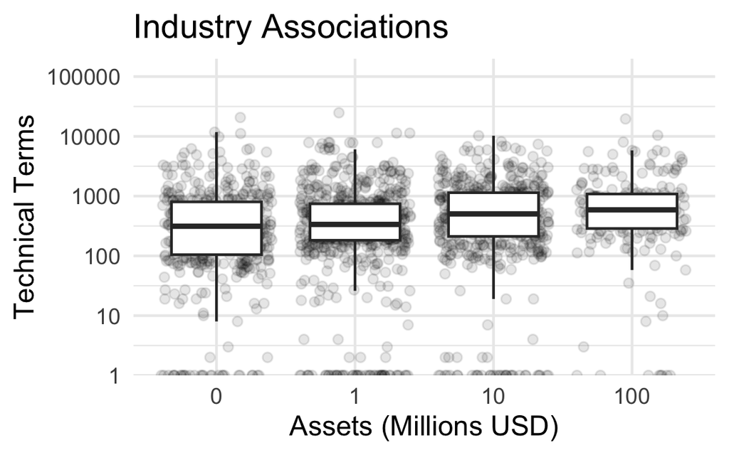

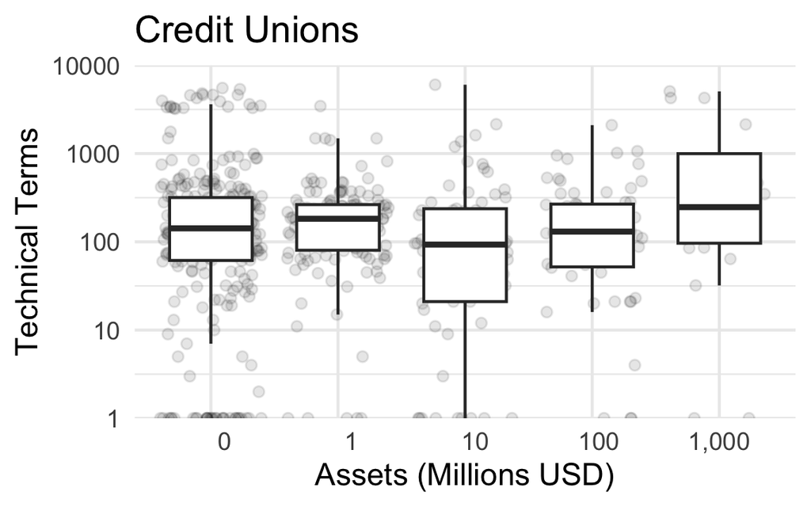

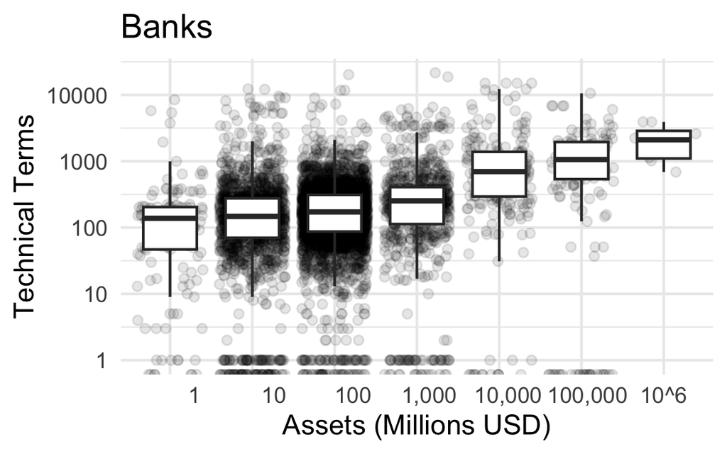

(d) Banks

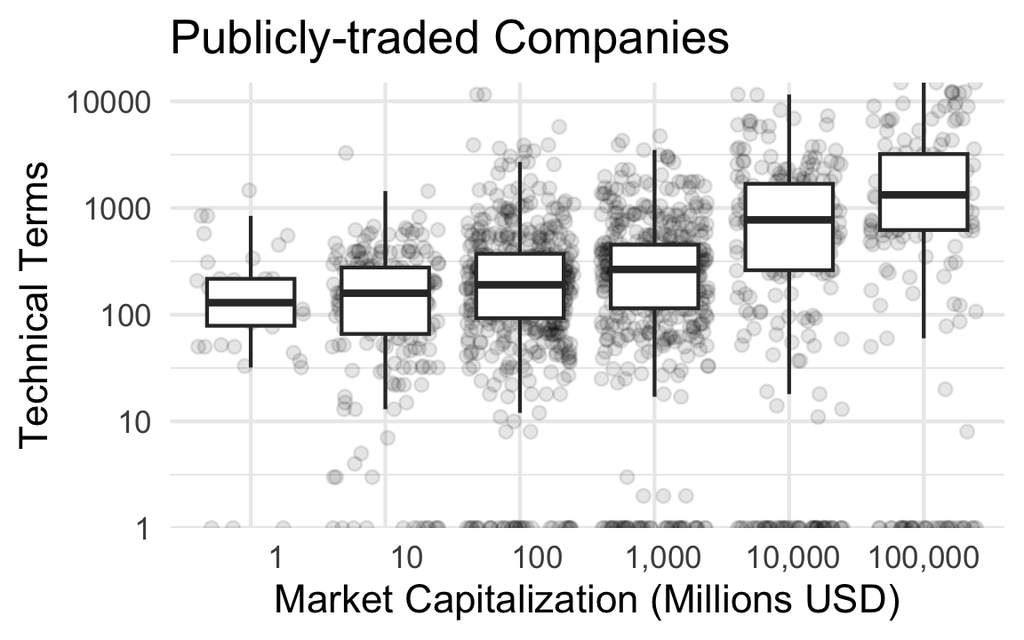

(e) Publicly-traded Companies

Figure 4: Amount of Technical Language by Assets. Each point represents a comment. The horizontal axis bins comments by orders of magnitude of the assets of the commenting organization in millions of dollars. Axis labels represent the lower bound of the bin.

## ACME 💰 $\rightsquigarrow$ sophistication (e.g., lawyers) $\rightsquigarrow$ lobbying success

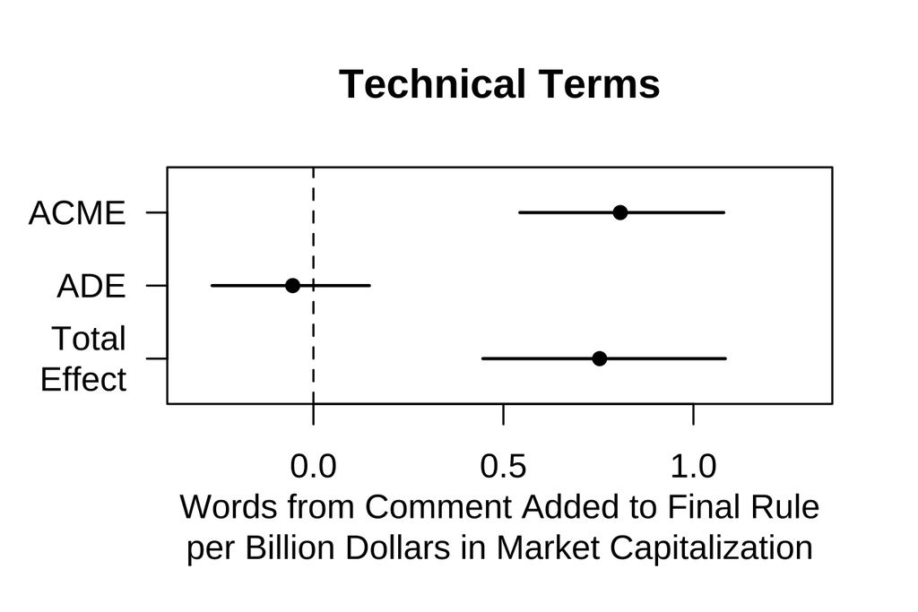

Technical Language as a Proposed Mediator Between Wealth and Lobbying Success

## Multiple Mediation

💰 $\rightsquigarrow$ sophistication (e.g., lawyers) $\rightsquigarrow$ lobbying success

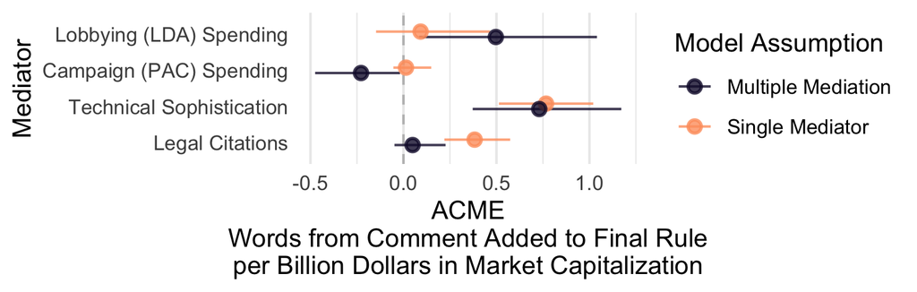

Lobbying Success by Comment Sophistication